# Risk Factor Analysis

## Outcome Variable

**Outcome Variable:** ever_sstunted

## Predictor Variables

**Intervention Variable:** feducyrs

**Adjustment Set:**

- arm
- W_mage
- meducyrs
- hhwealth_quart
- W_mhtcm
- W_mwtkg
- W_mbmi
- W_gagebrth
- W_birthwt
- W_birthlen
- single
- delta_W_mage
- delta_meducyrs
- delta_hhwealth_quart
- delta_W_mhtcm
- delta_W_mwtkg
- delta_W_mbmi
- delta_W_gagebrth
- delta_W_birthwt
- delta_W_birthlen
- delta_single

## Stratifying Variables

The analysis was stratified on these variable(s):

- agecat
- studyid
- country

## Data Summary

| agecat | studyid | country | feducyrs | ever_sstunted | n_cell | n |
| --- | --- | --- | --- | --- | --- | --- |
| 0-24 months | COHORTS | GUATEMALA | High | 0 | 128 | 1250 |
| 0-24 months | COHORTS | GUATEMALA | High | 1 | 106 | 1250 |
| 0-24 months | COHORTS | GUATEMALA | Low | 0 | 294 | 1250 |
| 0-24 months | COHORTS | GUATEMALA | Low | 1 | 273 | 1250 |
| 0-24 months | COHORTS | GUATEMALA | Medium | 0 | 237 | 1250 |
| 0-24 months | COHORTS | GUATEMALA | Medium | 1 | 212 | 1250 |
| 0-24 months | COHORTS | INDIA | High | 0 | 525 | 1447 |
| 0-24 months | COHORTS | INDIA | High | 1 | 42 | 1447 |
| 0-24 months | COHORTS | INDIA | Low | 0 | 397 | 1447 |
| 0-24 months | COHORTS | INDIA | Low | 1 | 75 | 1447 |
| 0-24 months | COHORTS | INDIA | Medium | 0 | 365 | 1447 |
| 0-24 months | COHORTS | INDIA | Medium | 1 | 43 | 1447 |
| 0-24 months | COHORTS | PHILIPPINES | High | 0 | 794 | 2880 |
| 0-24 months | COHORTS | PHILIPPINES | High | 1 | 237 | 2880 |
| 0-24 months | COHORTS | PHILIPPINES | Low | 0 | 424 | 2880 |
| 0-24 months | COHORTS | PHILIPPINES | Low | 1 | 404 | 2880 |
| 0-24 months | COHORTS | PHILIPPINES | Medium | 0 | 625 | 2880 |
| 0-24 months | COHORTS | PHILIPPINES | Medium | 1 | 396 | 2880 |
| 0-24 months | GMS-Nepal | NEPAL | High | 0 | 135 | 696 |
| 0-24 months | GMS-Nepal | NEPAL | High | 1 | 38 | 696 |
| 0-24 months | GMS-Nepal | NEPAL | Low | 0 | 217 | 696 |
| 0-24 months | GMS-Nepal | NEPAL | Low | 1 | 79 | 696 |
| 0-24 months | GMS-Nepal | NEPAL | Medium | 0 | 175 | 696 |
| 0-24 months | GMS-Nepal | NEPAL | Medium | 1 | 52 | 696 |
| 0-24 months | JiVitA-3 | BANGLADESH | High | 0 | 5711 | 26233 |
| 0-24 months | JiVitA-3 | BANGLADESH | High | 1 | 793 | 26233 |
| 0-24 months | JiVitA-3 | BANGLADESH | Low | 0 | 8589 | 26233 |
| 0-24 months | JiVitA-3 | BANGLADESH | Low | 1 | 2196 | 26233 |
| 0-24 months | JiVitA-3 | BANGLADESH | Medium | 0 | 7136 | 26233 |
| 0-24 months | JiVitA-3 | BANGLADESH | Medium | 1 | 1808 | 26233 |

[output cut: 90 more lines]

The following strata were considered:

- agecat: 0-24 months, studyid: COHORTS, country: GUATEMALA
- agecat: 0-24 months, studyid: COHORTS, country: INDIA
- agecat: 0-24 months, studyid: COHORTS, country: PHILIPPINES
- agecat: 0-24 months, studyid: GMS-Nepal, country: NEPAL
- agecat: 0-24 months, studyid: JiVitA-3, country: BANGLADESH
- agecat: 0-24 months, studyid: JiVitA-4, country: BANGLADESH
- agecat: 0-24 months, studyid: LCNI-5, country: MALAWI
- agecat: 0-24 months, studyid: MAL-ED, country: BANGLADESH
- agecat: 0-24 months, studyid: MAL-ED, country: INDIA
- agecat: 0-24 months, studyid: MAL-ED, country: NEPAL
- agecat: 0-24 months, studyid: MAL-ED, country: PERU
- agecat: 0-24 months, studyid: MAL-ED, country: SOUTH AFRICA
- agecat: 0-24 months, studyid: MAL-ED, country: TANZANIA, UNITED REPUBLIC OF
- agecat: 0-24 months, studyid: NIH-Crypto, country: BANGLADESH
- agecat: 0-24 months, studyid: PROBIT, country: BELARUS
- agecat: 0-24 months, studyid: PROVIDE, country: BANGLADESH
- agecat: 0-24 months, studyid: SAS-CompFeed, country: INDIA
- agecat: 0-24 months, studyid: SAS-FoodSuppl, country: INDIA
- agecat: 0-24 months, studyid: TanzaniaChild2, country: TANZANIA, UNITED REPUBLIC OF
- agecat: 0-24 months, studyid: ZVITAMBO, country: ZIMBABWE

### Dropped Strata

Some strata were dropped due to rare outcomes:

- agecat: 0-24 months, studyid: MAL-ED, country: NEPAL

## Methods Detail

We're interested in the causal parameters $E[Y_a]$ for all values of $a \in \mathcal{A}$. These parameters represent the mean outcome if, possibly contrary to fact, we intervened to set all units to have $A=a$. Under the randomization and positivity assumptions, these are identified by the statistical parameters $\psi_a=E_W[E_{Y|A,W}(Y|A=a,W)]$. In addition, we're interested in the mean of $Y$, $E[Y]$ under no intervention (the observed mean). We will estimate these parameters by using SuperLearner to fit the relevant likelihood factors -- $E_{Y|A,W}(Y|A=a,W)$ and $p(A=a|W)$, and then updating our likelihood fit using a joint TMLE.

For unadjusted analyses ($W=\{\}$), initial likelihoods were estimated using Lrnr_glm to estimate the simple $E(Y|A)$ and Lrnr_mean to estimate $p(A)$. For adjusted analyses, a small library containing Lrnr_glmnet, Lrnr_xgboost, and Lrnr_mean was used.

Having estimated these parameters, we will then use the delta method to estimate relative risks and attributable risks relative to a prespecified baseline level of $A$.

# Results Detail

## Results Plots

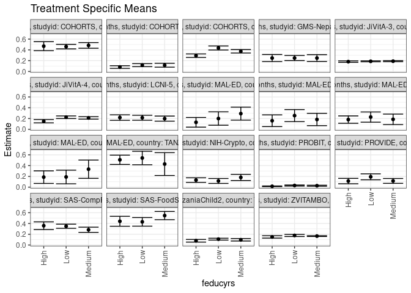

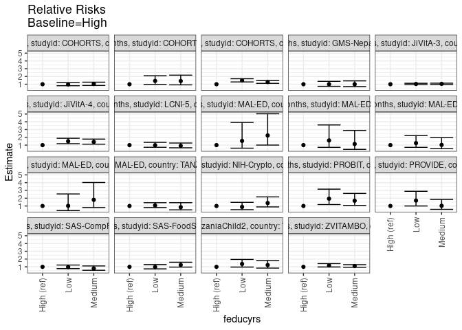

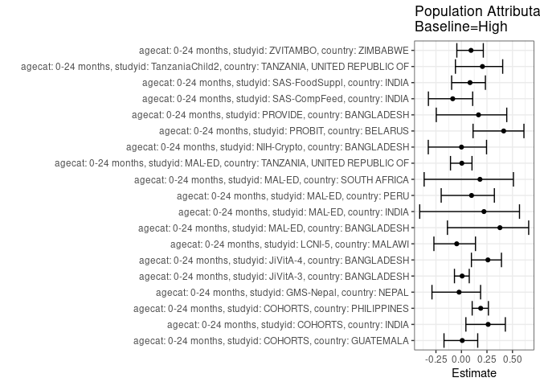

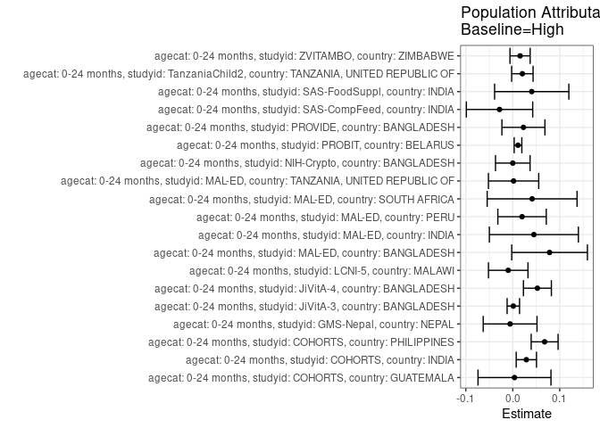

## Results Table

### Parameter: TSM

| agecat | studyid | country | intervention_level | baseline_level | estimate | ci_lower | ci_upper |
| --- | --- | --- | --- | --- | --- | --- | --- |
| 0-24 months | COHORTS | GUATEMALA | High | NA | 0.4691330 | 0.3859364 | 0.5523297 |
| 0-24 months | COHORTS | GUATEMALA | Low | NA | 0.4605218 | 0.4186691 | 0.5023746 |
| 0-24 months | COHORTS | GUATEMALA | Medium | NA | 0.4831036 | 0.4307869 | 0.5354204 |
| 0-24 months | COHORTS | INDIA | High | NA | 0.0816467 | 0.0575006 | 0.1057928 |
| 0-24 months | COHORTS | INDIA | Low | NA | 0.1167473 | 0.0887981 | 0.1446966 |
| 0-24 months | COHORTS | INDIA | Medium | NA | 0.1153548 | 0.0791492 | 0.1515605 |
| 0-24 months | COHORTS | PHILIPPINES | High | NA | 0.2921867 | 0.2597774 | 0.3245960 |
| 0-24 months | COHORTS | PHILIPPINES | Low | NA | 0.4349910 | 0.3977726 | 0.4722093 |
| 0-24 months | COHORTS | PHILIPPINES | Medium | NA | 0.3739566 | 0.3419911 | 0.4059222 |
| 0-24 months | GMS-Nepal | NEPAL | High | NA | 0.2484792 | 0.1833286 | 0.3136297 |
| 0-24 months | GMS-Nepal | NEPAL | Low | NA | 0.2489785 | 0.2006194 | 0.2973376 |
| 0-24 months | GMS-Nepal | NEPAL | Medium | NA | 0.2482202 | 0.1851133 | 0.3113272 |
| 0-24 months | JiVitA-3 | BANGLADESH | High | NA | 0.1816748 | 0.1673388 | 0.1960107 |
| 0-24 months | JiVitA-3 | BANGLADESH | Low | NA | 0.1875723 | 0.1789396 | 0.1962050 |
| 0-24 months | JiVitA-3 | BANGLADESH | Medium | NA | 0.1900924 | 0.1813235 | 0.1988613 |
| 0-24 months | JiVitA-4 | BANGLADESH | High | NA | 0.1499314 | 0.1189086 | 0.1809542 |
| 0-24 months | JiVitA-4 | BANGLADESH | Low | NA | 0.2240273 | 0.1998475 | 0.2482071 |
| 0-24 months | JiVitA-4 | BANGLADESH | Medium | NA | 0.2112310 | 0.1886469 | 0.2338151 |
| 0-24 months | LCNI-5 | MALAWI | High | NA | 0.2175459 | 0.1666303 | 0.2684616 |
| 0-24 months | LCNI-5 | MALAWI | Low | NA | 0.2147915 | 0.1683041 | 0.2612789 |
| 0-24 months | LCNI-5 | MALAWI | Medium | NA | 0.1981038 | 0.1506933 | 0.2455142 |
| 0-24 months | MAL-ED | BANGLADESH | High | NA | 0.1296296 | 0.0397383 | 0.2195209 |
| 0-24 months | MAL-ED | BANGLADESH | Low | NA | 0.2000000 | 0.0756229 | 0.3243771 |
| 0-24 months | MAL-ED | BANGLADESH | Medium | NA | 0.2909091 | 0.1704725 | 0.4113457 |
| 0-24 months | MAL-ED | INDIA | High | NA | 0.1590909 | 0.0506480 | 0.2675338 |
| 0-24 months | MAL-ED | INDIA | Low | NA | 0.2542373 | 0.1427503 | 0.3657243 |
| 0-24 months | MAL-ED | INDIA | Medium | NA | 0.1818182 | 0.0674652 | 0.2961712 |
| 0-24 months | MAL-ED | PERU | High | NA | 0.1802244 | 0.1119092 | 0.2485396 |
| 0-24 months | MAL-ED | PERU | Low | NA | 0.2268067 | 0.1319236 | 0.3216898 |
| 0-24 months | MAL-ED | PERU | Medium | NA | 0.1847719 | 0.0871501 | 0.2823936 |
| 0-24 months | MAL-ED | SOUTH AFRICA | High | NA | 0.1860465 | 0.0692022 | 0.3028908 |
| 0-24 months | MAL-ED | SOUTH AFRICA | Low | NA | 0.1891892 | 0.0624128 | 0.3159655 |
| 0-24 months | MAL-ED | SOUTH AFRICA | Medium | NA | 0.3333333 | 0.1638745 | 0.5027922 |
| 0-24 months | MAL-ED | TANZANIA, UNITED REPUBLIC OF | High | NA | 0.5076923 | 0.4215490 | 0.5938357 |
| 0-24 months | MAL-ED | TANZANIA, UNITED REPUBLIC OF | Low | NA | 0.5409836 | 0.4156360 | 0.6663312 |
| 0-24 months | MAL-ED | TANZANIA, UNITED REPUBLIC OF | Medium | NA | 0.4285714 | 0.2164143 | 0.6407286 |
| 0-24 months | NIH-Crypto | BANGLADESH | High | NA | 0.1305670 | 0.0879095 | 0.1732245 |
| 0-24 months | NIH-Crypto | BANGLADESH | Low | NA | 0.1147761 | 0.0691022 | 0.1604500 |
| 0-24 months | NIH-Crypto | BANGLADESH | Medium | NA | 0.1802703 | 0.1231796 | 0.2373611 |
| 0-24 months | PROBIT | BELARUS | High | NA | 0.0158127 | 0.0093811 | 0.0222442 |
| 0-24 months | PROBIT | BELARUS | Low | NA | 0.0306043 | 0.0211494 | 0.0400591 |
| 0-24 months | PROBIT | BELARUS | Medium | NA | 0.0264711 | 0.0170021 | 0.0359400 |
| 0-24 months | PROVIDE | BANGLADESH | High | NA | 0.1130184 | 0.0627659 | 0.1632710 |
| 0-24 months | PROVIDE | BANGLADESH | Low | NA | 0.1920946 | 0.1366538 | 0.2475355 |
| 0-24 months | PROVIDE | BANGLADESH | Medium | NA | 0.1153749 | 0.0704349 | 0.1603149 |
| 0-24 months | SAS-CompFeed | INDIA | High | NA | 0.3582798 | 0.2868771 | 0.4296826 |
| 0-24 months | SAS-CompFeed | INDIA | Low | NA | 0.3486000 | 0.3101667 | 0.3870333 |
| 0-24 months | SAS-CompFeed | INDIA | Medium | NA | 0.2827466 | 0.2345754 | 0.3309179 |
| 0-24 months | SAS-FoodSuppl | INDIA | High | NA | 0.4404614 | 0.3483418 | 0.5325811 |
| 0-24 months | SAS-FoodSuppl | INDIA | Low | NA | 0.4299276 | 0.3498107 | 0.5100445 |
| 0-24 months | SAS-FoodSuppl | INDIA | Medium | NA | 0.5465644 | 0.4698709 | 0.6232579 |
| 0-24 months | TanzaniaChild2 | TANZANIA, UNITED REPUBLIC OF | High | NA | 0.0790125 | 0.0543616 | 0.1036634 |
| 0-24 months | TanzaniaChild2 | TANZANIA, UNITED REPUBLIC OF | Low | NA | 0.1086450 | 0.0914000 | 0.1258901 |
| 0-24 months | TanzaniaChild2 | TANZANIA, UNITED REPUBLIC OF | Medium | NA | 0.0973738 | 0.0748407 | 0.1199068 |
| 0-24 months | ZVITAMBO | ZIMBABWE | High | NA | 0.1505112 | 0.1283898 | 0.1726326 |
| 0-24 months | ZVITAMBO | ZIMBABWE | Low | NA | 0.1775039 | 0.1577549 | 0.1972530 |
| 0-24 months | ZVITAMBO | ZIMBABWE | Medium | NA | 0.1656155 | 0.1581071 | 0.1731238 |

### Parameter: E(Y)

| agecat | studyid | country | intervention_level | baseline_level | estimate | ci_lower | ci_upper |
| --- | --- | --- | --- | --- | --- | --- | --- |
| 0-24 months | COHORTS | GUATEMALA | NA | NA | 0.4728000 | 0.4451119 | 0.5004881 |
| 0-24 months | COHORTS | INDIA | NA | NA | 0.1105736 | 0.0944098 | 0.1267374 |
| 0-24 months | COHORTS | PHILIPPINES | NA | NA | 0.3600694 | 0.3425352 | 0.3776037 |
| 0-24 months | GMS-Nepal | NEPAL | NA | NA | 0.2428161 | 0.2109378 | 0.2746944 |
| 0-24 months | JiVitA-3 | BANGLADESH | NA | NA | 0.1828613 | 0.1771578 | 0.1885648 |
| 0-24 months | JiVitA-4 | BANGLADESH | NA | NA | 0.2024261 | 0.1900868 | 0.2147654 |
| 0-24 months | LCNI-5 | MALAWI | NA | NA | 0.2078721 | 0.1799617 | 0.2357825 |
| 0-24 months | MAL-ED | BANGLADESH | NA | NA | 0.2080537 | 0.1426574 | 0.2734499 |
| 0-24 months | MAL-ED | INDIA | NA | NA | 0.2040816 | 0.1387072 | 0.2694561 |
| 0-24 months | MAL-ED | PERU | NA | NA | 0.2000000 | 0.1503169 | 0.2496831 |
| 0-24 months | MAL-ED | SOUTH AFRICA | NA | NA | 0.2272727 | 0.1486005 | 0.3059450 |
| 0-24 months | MAL-ED | TANZANIA, UNITED REPUBLIC OF | NA | NA | 0.5094340 | 0.4419812 | 0.5768867 |
| 0-24 months | NIH-Crypto | BANGLADESH | NA | NA | 0.1306069 | 0.1066024 | 0.1546113 |
| 0-24 months | PROBIT | BELARUS | NA | NA | 0.0269707 | 0.0195564 | 0.0343850 |
| 0-24 months | PROVIDE | BANGLADESH | NA | NA | 0.1357143 | 0.1103250 | 0.1611036 |
| 0-24 months | SAS-CompFeed | INDIA | NA | NA | 0.3300654 | 0.3020915 | 0.3580392 |
| 0-24 months | SAS-FoodSuppl | INDIA | NA | NA | 0.4808612 | 0.4329065 | 0.5288160 |
| 0-24 months | TanzaniaChild2 | TANZANIA, UNITED REPUBLIC OF | NA | NA | 0.0994545 | 0.0874362 | 0.1114727 |
| 0-24 months | ZVITAMBO | ZIMBABWE | NA | NA | 0.1660581 | 0.1598251 | 0.1722911 |

### Parameter: RR

| agecat | studyid | country | intervention_level | baseline_level | estimate | ci_lower | ci_upper |
| --- | --- | --- | --- | --- | --- | --- | --- |
| 0-24 months | COHORTS | GUATEMALA | High | High | 1.0000000 | 1.0000000 | 1.000000 |
| 0-24 months | COHORTS | GUATEMALA | Low | High | 0.9816445 | 0.8061107 | 1.195401 |
| 0-24 months | COHORTS | GUATEMALA | Medium | High | 1.0297796 | 0.8384222 | 1.264811 |
| 0-24 months | COHORTS | INDIA | High | High | 1.0000000 | 1.0000000 | 1.000000 |
| 0-24 months | COHORTS | INDIA | Low | High | 1.4299087 | 0.9786898 | 2.089160 |
| 0-24 months | COHORTS | INDIA | Medium | High | 1.4128539 | 0.9197720 | 2.170273 |
| 0-24 months | COHORTS | PHILIPPINES | High | High | 1.0000000 | 1.0000000 | 1.000000 |
| 0-24 months | COHORTS | PHILIPPINES | Low | High | 1.4887432 | 1.2968528 | 1.709027 |
| 0-24 months | COHORTS | PHILIPPINES | Medium | High | 1.2798552 | 1.1155229 | 1.468396 |
| 0-24 months | GMS-Nepal | NEPAL | High | High | 1.0000000 | 1.0000000 | 1.000000 |
| 0-24 months | GMS-Nepal | NEPAL | Low | High | 1.0020094 | 0.7310747 | 1.373352 |
| 0-24 months | GMS-Nepal | NEPAL | Medium | High | 0.9989579 | 0.6972439 | 1.431231 |
| 0-24 months | JiVitA-3 | BANGLADESH | High | High | 1.0000000 | 1.0000000 | 1.000000 |
| 0-24 months | JiVitA-3 | BANGLADESH | Low | High | 1.0324618 | 0.9496845 | 1.122454 |
| 0-24 months | JiVitA-3 | BANGLADESH | Medium | High | 1.0463337 | 0.9610021 | 1.139242 |
| 0-24 months | JiVitA-4 | BANGLADESH | High | High | 1.0000000 | 1.0000000 | 1.000000 |
| 0-24 months | JiVitA-4 | BANGLADESH | Low | High | 1.4941986 | 1.1859522 | 1.882563 |
| 0-24 months | JiVitA-4 | BANGLADESH | Medium | High | 1.4088510 | 1.1204276 | 1.771521 |
| 0-24 months | LCNI-5 | MALAWI | High | High | 1.0000000 | 1.0000000 | 1.000000 |
| 0-24 months | LCNI-5 | MALAWI | Low | High | 0.9873385 | 0.7210363 | 1.351995 |
| 0-24 months | LCNI-5 | MALAWI | Medium | High | 0.9106297 | 0.6538006 | 1.268347 |
| 0-24 months | MAL-ED | BANGLADESH | High | High | 1.0000000 | 1.0000000 | 1.000000 |
| 0-24 months | MAL-ED | BANGLADESH | Low | High | 1.5428571 | 0.6078543 | 3.916084 |
| 0-24 months | MAL-ED | BANGLADESH | Medium | High | 2.2441558 | 1.0006999 | 5.032713 |
| 0-24 months | MAL-ED | INDIA | High | High | 1.0000000 | 1.0000000 | 1.000000 |
| 0-24 months | MAL-ED | INDIA | Low | High | 1.5980630 | 0.7105469 | 3.594140 |
| 0-24 months | MAL-ED | INDIA | Medium | High | 1.1428571 | 0.4520604 | 2.889265 |
| 0-24 months | MAL-ED | PERU | High | High | 1.0000000 | 1.0000000 | 1.000000 |
| 0-24 months | MAL-ED | PERU | Low | High | 1.2584684 | 0.7140354 | 2.218017 |
| 0-24 months | MAL-ED | PERU | Medium | High | 1.0252321 | 0.5351913 | 1.963972 |
| 0-24 months | MAL-ED | SOUTH AFRICA | High | High | 1.0000000 | 1.0000000 | 1.000000 |
| 0-24 months | MAL-ED | SOUTH AFRICA | Low | High | 1.0168919 | 0.4058970 | 2.547614 |
| 0-24 months | MAL-ED | SOUTH AFRICA | Medium | High | 1.7916667 | 0.7986258 | 4.019491 |
| 0-24 months | MAL-ED | TANZANIA, UNITED REPUBLIC OF | High | High | 1.0000000 | 1.0000000 | 1.000000 |
| 0-24 months | MAL-ED | TANZANIA, UNITED REPUBLIC OF | Low | High | 1.0655738 | 0.7995761 | 1.420062 |
| 0-24 months | MAL-ED | TANZANIA, UNITED REPUBLIC OF | Medium | High | 0.8441558 | 0.5002121 | 1.424594 |
| 0-24 months | NIH-Crypto | BANGLADESH | High | High | 1.0000000 | 1.0000000 | 1.000000 |
| 0-24 months | NIH-Crypto | BANGLADESH | Low | High | 0.8790590 | 0.5258704 | 1.469459 |
| 0-24 months | NIH-Crypto | BANGLADESH | Medium | High | 1.3806731 | 0.8786428 | 2.169548 |
| 0-24 months | PROBIT | BELARUS | High | High | 1.0000000 | 1.0000000 | 1.000000 |
| 0-24 months | PROBIT | BELARUS | Low | High | 1.9354244 | 1.1837294 | 3.164463 |
| 0-24 months | PROBIT | BELARUS | Medium | High | 1.6740394 | 1.0713846 | 2.615688 |
| 0-24 months | PROVIDE | BANGLADESH | High | High | 1.0000000 | 1.0000000 | 1.000000 |
| 0-24 months | PROVIDE | BANGLADESH | Low | High | 1.6996752 | 1.0006329 | 2.887069 |
| 0-24 months | PROVIDE | BANGLADESH | Medium | High | 1.0208505 | 0.5655305 | 1.842758 |
| 0-24 months | SAS-CompFeed | INDIA | High | High | 1.0000000 | 1.0000000 | 1.000000 |
| 0-24 months | SAS-CompFeed | INDIA | Low | High | 0.9729824 | 0.7678020 | 1.232993 |
| 0-24 months | SAS-CompFeed | INDIA | Medium | High | 0.7891782 | 0.5582640 | 1.115605 |
| 0-24 months | SAS-FoodSuppl | INDIA | High | High | 1.0000000 | 1.0000000 | 1.000000 |
| 0-24 months | SAS-FoodSuppl | INDIA | Low | High | 0.9760846 | 0.7390106 | 1.289212 |
| 0-24 months | SAS-FoodSuppl | INDIA | Medium | High | 1.2408905 | 0.9667479 | 1.592772 |
| 0-24 months | TanzaniaChild2 | TANZANIA, UNITED REPUBLIC OF | High | High | 1.0000000 | 1.0000000 | 1.000000 |
| 0-24 months | TanzaniaChild2 | TANZANIA, UNITED REPUBLIC OF | Low | High | 1.3750369 | 0.9697331 | 1.949739 |
| 0-24 months | TanzaniaChild2 | TANZANIA, UNITED REPUBLIC OF | Medium | High | 1.2323850 | 0.8368201 | 1.814933 |
| 0-24 months | ZVITAMBO | ZIMBABWE | High | High | 1.0000000 | 1.0000000 | 1.000000 |
| 0-24 months | ZVITAMBO | ZIMBABWE | Low | High | 1.1793404 | 0.9825824 | 1.415498 |
| 0-24 months | ZVITAMBO | ZIMBABWE | Medium | High | 1.1003532 | 0.9456676 | 1.280341 |

### Parameter: PAR

| agecat | studyid | country | intervention_level | baseline_level | estimate | ci_lower | ci_upper |
| --- | --- | --- | --- | --- | --- | --- | --- |
| 0-24 months | COHORTS | GUATEMALA | High | NA | 0.0036670 | -0.0740643 | 0.0813982 |
| 0-24 months | COHORTS | INDIA | High | NA | 0.0289269 | 0.0073206 | 0.0505332 |
| 0-24 months | COHORTS | PHILIPPINES | High | NA | 0.0678828 | 0.0392056 | 0.0965599 |
| 0-24 months | GMS-Nepal | NEPAL | High | NA | -0.0056631 | -0.0629756 | 0.0516494 |
| 0-24 months | JiVitA-3 | BANGLADESH | High | NA | 0.0011865 | -0.0120503 | 0.0144233 |
| 0-24 months | JiVitA-4 | BANGLADESH | High | NA | 0.0524947 | 0.0227210 | 0.0822683 |
| 0-24 months | LCNI-5 | MALAWI | High | NA | -0.0096738 | -0.0517764 | 0.0324287 |
| 0-24 months | MAL-ED | BANGLADESH | High | NA | 0.0784241 | -0.0021994 | 0.1590476 |
| 0-24 months | MAL-ED | INDIA | High | NA | 0.0449907 | -0.0498447 | 0.1398262 |
| 0-24 months | MAL-ED | PERU | High | NA | 0.0197756 | -0.0318386 | 0.0713898 |
| 0-24 months | MAL-ED | SOUTH AFRICA | High | NA | 0.0412262 | -0.0545238 | 0.1369763 |
| 0-24 months | MAL-ED | TANZANIA, UNITED REPUBLIC OF | High | NA | 0.0017417 | -0.0518281 | 0.0553114 |
| 0-24 months | NIH-Crypto | BANGLADESH | High | NA | 0.0000399 | -0.0367619 | 0.0368417 |
| 0-24 months | PROBIT | BELARUS | High | NA | 0.0111580 | 0.0030082 | 0.0193078 |
| 0-24 months | PROVIDE | BANGLADESH | High | NA | 0.0226959 | -0.0231402 | 0.0685319 |
| 0-24 months | SAS-CompFeed | INDIA | High | NA | -0.0282145 | -0.0988921 | 0.0424632 |
| 0-24 months | SAS-FoodSuppl | INDIA | High | NA | 0.0403998 | -0.0386938 | 0.1194934 |
| 0-24 months | TanzaniaChild2 | TANZANIA, UNITED REPUBLIC OF | High | NA | 0.0204420 | -0.0024082 | 0.0432922 |
| 0-24 months | ZVITAMBO | ZIMBABWE | High | NA | 0.0155469 | -0.0059400 | 0.0370339 |

### Parameter: PAF

| agecat | studyid | country | intervention_level | baseline_level | estimate | ci_lower | ci_upper |
| --- | --- | --- | --- | --- | --- | --- | --- |
| 0-24 months | COHORTS | GUATEMALA | High | NA | 0.0077559 | -0.1710700 | 0.1592745 |
| 0-24 months | COHORTS | INDIA | High | NA | 0.2616078 | 0.0434284 | 0.4300238 |
| 0-24 months | COHORTS | PHILIPPINES | High | NA | 0.1885268 | 0.1050608 | 0.2642084 |
| 0-24 months | GMS-Nepal | NEPAL | High | NA | -0.0233226 | -0.2888796 | 0.1875199 |
| 0-24 months | JiVitA-3 | BANGLADESH | High | NA | 0.0064885 | -0.0685980 | 0.0762990 |
| 0-24 months | JiVitA-4 | BANGLADESH | High | NA | 0.2593275 | 0.0975912 | 0.3920763 |
| 0-24 months | LCNI-5 | MALAWI | High | NA | -0.0465375 | -0.2699907 | 0.1375995 |
| 0-24 months | MAL-ED | BANGLADESH | High | NA | 0.3769415 | -0.1376520 | 0.6587692 |
| 0-24 months | MAL-ED | INDIA | High | NA | 0.2204545 | -0.4090534 | 0.5687239 |
| 0-24 months | MAL-ED | PERU | High | NA | 0.0988780 | -0.1985289 | 0.3224853 |
| 0-24 months | MAL-ED | SOUTH AFRICA | High | NA | 0.1813953 | -0.3655131 | 0.5092588 |
| 0-24 months | MAL-ED | TANZANIA, UNITED REPUBLIC OF | High | NA | 0.0034188 | -0.1074860 | 0.1032175 |
| 0-24 months | NIH-Crypto | BANGLADESH | High | NA | 0.0003053 | -0.3251858 | 0.2458495 |
| 0-24 months | PROBIT | BELARUS | High | NA | 0.4137086 | 0.1136074 | 0.6122062 |
| 0-24 months | PROVIDE | BANGLADESH | High | NA | 0.1672326 | -0.2470023 | 0.4438651 |
| 0-24 months | SAS-CompFeed | INDIA | High | NA | -0.0854815 | -0.3238563 | 0.1099713 |
| 0-24 months | SAS-FoodSuppl | INDIA | High | NA | 0.0840156 | -0.0963244 | 0.2346905 |
| 0-24 months | TanzaniaChild2 | TANZANIA, UNITED REPUBLIC OF | High | NA | 0.2055414 | -0.0591171 | 0.4040654 |
| 0-24 months | ZVITAMBO | ZIMBABWE | High | NA | 0.0936235 | -0.0453481 | 0.2141198 |